# Spatial Mixed-Effects Modelling

Nicolas Canete and Ellis Patrick

Westmead Institute for Medical Research, University of Sydney, Australia  
School of Mathematics and Statistics, University of Sydney, Australia

nicolas.canete@sydney.edu.au

8 April 2020

#### Package

spicyR 0.99.8

# Contents

```r
# load required packages
library(spicyR)
library(ggplot2)
```

# 1 Overview

This guide will provide a step-by-step guide on how mixed effects models can be applied to multiple segmented and labelled images to identify how the localisation of different cell types can change across different conditions. Here, the subject is modelled as a random effect, and the different conditions are modelled as a fixed effect.

# 2 Example data

Here, we use a melanoma image dataset with two conditions: Responders and Non-Responders. With this data set, we want to see if there are differences in how cell types are localised with respect to each other.

`cells` is a `segmentedCells` object containing single-cell data of 135 images from 27 subjects, with 5 images per subjects. There are 9 Non-Responder subjects and 18 Responder subjects.

`location()` returns a `DataFrame` object providing the location (`x` and `y`) and cell type (`cellType`) of each cell and the image it belongs to (`imageID`).

`phenotype()` returns a `DataFrame` object providing the corresponding subject (`subject`) and condition (`condition`) for each image.

```r
data("melanomaResponders")
melanomaResponders
```

```
## A segmentedCells with...
## Number of images: 135
## Number of cells: 296523
## Number of cell types: 9 [ CD8-PD1-PDL1-, SOX10+, ..., CD8-PD1-PDL1+ ]
## Number of intensities: 0 [ ]
## Number of morphologies: 0 [ ]
## Number of image phenotypes: 3 [ imageID, condition, subject ]
```

```r
location(melanomaResponders)
```

```
## DataFrame with 296523 rows and 6 columns
##            imageID      cellID imageCellID         x         y      cellType
##        <character> <character> <character> <numeric> <numeric>      <factor>
## 1                1      cell_1      cell_1      49.5      1.25 CD8-PD1-PDL1-
## 2                1      cell_2      cell_2        85         1 CD8-PD1-PDL1-
## 3                1      cell_3      cell_3       169      1.25        SOX10+
## 4                1      cell_4      cell_4       245         1 CD8-PD1-PDL1-
## 5                1      cell_5      cell_5       291         1        SOX10+
## ...            ...         ...         ...       ...       ...           ...
## 296519         525 cell_176846 cell_176846    170.25    248.25        SOX10+
## 296520         525 cell_176847 cell_176847      66.5    248.75        SOX10+
## 296521         525 cell_176848 cell_176848       123    248.25        SOX10+
## 296522         525 cell_176849 cell_176849     202.5    248.25 CD8-PD1-PDL1-
## 296523         525 cell_176850 cell_176850     110.5    248.75        SOX10+
```

```r
phenotype(melanomaResponders)
```

```
## DataFrame with 135 rows and 3 columns
##       imageID      condition    subject
##     <numeric>       <factor>   <factor>
## 1           1 Non-Responders SP12-18569
## 2           2 Non-Responders SP12-18569
## 3           3 Non-Responders SP12-18569
## 4           4 Non-Responders SP12-18569
## 5           5 Non-Responders SP12-18569
## ...       ...            ...        ...
## 521       521     Responders SW14-18104
## 522       522     Responders SW14-18104
## 523       523     Responders SW14-18104
## 524       524     Responders SW14-18104
## 525       525     Responders SW14-18104
```

In this data set, `cellType` can be some combination of the expression of CD8, PD1 or PDL1, or is SOX10+.

# 3 Mixed Effects Modelling

To investigate changes in colocalisation between two different cell types, we measure the level of colocalisation between two cell types by modelling with the `Lcross()` function in the `spatstat` package. Specifically, the mean difference between the obtained function and the theoretical function is used as a measure for the level of colocalisation. Differences of this statistic between two conditions is modelled using a weighted mixed effects model, with condition as the fixed effect and subject as the random effect.

## 3.1 Testing for change in colocalisation between Responders and Non-Responders

for a specific pair of cells

Firstly, we can see whether one cell type tends to be around another cell type in one condition compared to the other. This can be done using the `spicy()` function, where we include `condition`, and `subject`. In this example, we want to see whether or not CD8-PD1+PDL1+ cells (`to`) thend to be found around CD8+PD1+PDL1- cells (`from`).

```r
spicyTestPair <- spicy(melanomaResponders,
                   condition = "condition",
                   subject = "subject",
                   from = "CD8+PD1+PDL1-",
                   to = "CD8-PD1+PDL1+")
```

```
## Calculating pairwise spatial associations
```

```
## Testing for spatial differences across conditions accounting for multiple images per subject
```

```
## boundary (singular) fit: see ?isSingular
```

```r
spicyTestPair
```

```
## Number of cell type pairs:  1
## Number of differentially localised cell type pairs:
## [1] 1
```

```r
top(spicyTestPair)
```

[output not shown]

We obtain a `spicy` object which details the results of the mixed effects modelling performed. As the `coefficient` in `spicyTest` is negative, we find that CD8-PD1+PDL1+ cells are more likely to be found around CD8+PD1+PDL1- cells in Non-Responders.

## 3.2 Test for change in colocalisation between Responders and Non-Responders for

all pairwise cell combinations

Here, we can perform what we did above for all pairwise combinations of cell types by excluding the `from` and `to` parameters from `spicy()`.

```r
spicyTest <- spicy(melanomaResponders,
                   condition = "condition",
                   subject = "subject")
```

```r
spicyTest
```

```
## Number of cell type pairs:  81
## Number of differentially localised cell type pairs:
## conditionResponders
##                   0
```

```r
top(spicyTest)
```

```
##                             intercept coefficient     p.value adj.pvalue
## CD8-PD1+PDL1+_CD8+PD1+PDL1- 21.403625  -14.143257 0.006696371  0.3184453
## CD8+PD1+PDL1-_CD8-PD1+PDL1+ 21.300751  -13.854313 0.007862848  0.3184453
## CD8-PD1+PDL1-_CD8+PD1-PDL1+  6.348714   -7.144476 0.076475111  0.9174987
## CD8-PD1+PDL1-_CD8-PD1+PDL1+ 12.485009   -7.625312 0.081119183  0.9174987
## CD8+PD1-PDL1-_CD8+PD1-PDL1- 20.934811  -11.403936 0.093658867  0.9174987
## CD8-PD1+PDL1+_CD8-PD1+PDL1- 11.621590   -6.942920 0.112733933  0.9174987
## CD8+PD1-PDL1+_CD8-PD1+PDL1-  4.821599   -6.028484 0.119793885  0.9174987
## CD8+PD1-PDL1-_CD8+PD1+PDL1- 11.049319    7.124038 0.123391930  0.9174987
## CD8-PD1-PDL1-_CD8+PD1-PDL1-  9.067690   -2.765159 0.141393584  0.9174987
## CD8+PD1+PDL1-_CD8+PD1-PDL1- 11.041912    6.860201 0.143290192  0.9174987
##                                      from            to
## CD8-PD1+PDL1+_CD8+PD1+PDL1- CD8-PD1+PDL1+ CD8+PD1+PDL1-
## CD8+PD1+PDL1-_CD8-PD1+PDL1+ CD8+PD1+PDL1- CD8-PD1+PDL1+
## CD8-PD1+PDL1-_CD8+PD1-PDL1+ CD8-PD1+PDL1- CD8+PD1-PDL1+
## CD8-PD1+PDL1-_CD8-PD1+PDL1+ CD8-PD1+PDL1- CD8-PD1+PDL1+
## CD8+PD1-PDL1-_CD8+PD1-PDL1- CD8+PD1-PDL1- CD8+PD1-PDL1-
## CD8-PD1+PDL1+_CD8-PD1+PDL1- CD8-PD1+PDL1+ CD8-PD1+PDL1-
## CD8+PD1-PDL1+_CD8-PD1+PDL1- CD8+PD1-PDL1+ CD8-PD1+PDL1-
## CD8+PD1-PDL1-_CD8+PD1+PDL1- CD8+PD1-PDL1- CD8+PD1+PDL1-
## CD8-PD1-PDL1-_CD8+PD1-PDL1- CD8-PD1-PDL1- CD8+PD1-PDL1-
## CD8+PD1+PDL1-_CD8+PD1-PDL1- CD8+PD1+PDL1- CD8+PD1-PDL1-
```

Again, we obtain a `spicy` object which outlines the result of the mixed effects models performed for each pairwise combination if cell types.

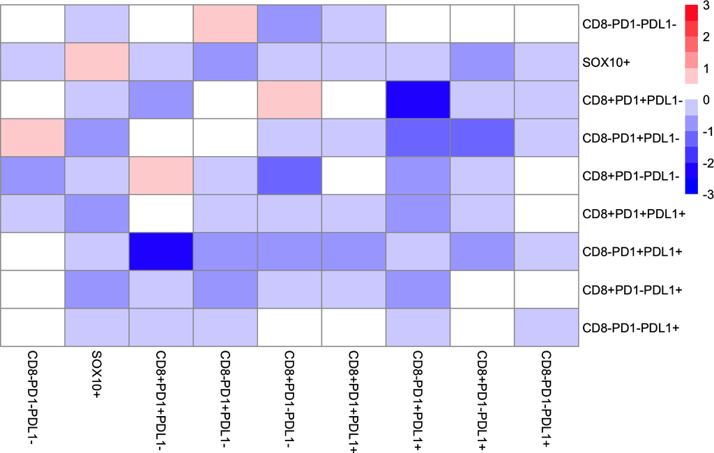

```r
signifPlot(spicyTest, breaks=c(-3, 3, 0.5))
```

### 3.2.1 Bootstrapping with spicy

There are multiple ways for calculating p-values for mixed effects models. We have also implemented a bootstrapping approach. All that is needed is a choice for the number of resamples used in the bootstrap which can be set with the `nsim` parameter in `spicy()`.

```r
spicyTestBootstrap <- spicy(melanomaResponders,
                   condition = "condition",
                   subject = "subject",
                   nsim = 199)
```

```r
spicyTestBootstrap
```

```
## Number of cell type pairs:  81
## Number of differentially localised cell type pairs:
## conditionResponders
##                  14
```

```r
top(spicyTestBootstrap)
```

```
##                             intercept coefficient p.value adj.pvalue
## CD8+PD1+PDL1+_SOX10+        -1.849790   -2.277733       0          0
## CD8+PD1+PDL1-_CD8+PD1+PDL1- 20.643857   -9.966505       0          0
## CD8+PD1-PDL1-_CD8+PD1+PDL1- 11.049319    7.124038       0          0
## CD8-PD1+PDL1+_CD8+PD1+PDL1- 21.403625  -14.143257       0          0
## CD8+PD1+PDL1+_CD8-PD1+PDL1-  6.579050   -2.957959       0          0
## CD8-PD1+PDL1+_CD8-PD1+PDL1- 11.621590   -6.942920       0          0
## CD8+PD1-PDL1+_CD8-PD1+PDL1-  4.821599   -6.028484       0          0
## CD8-PD1-PDL1+_CD8-PD1+PDL1-  4.438305   -2.245794       0          0
## CD8+PD1+PDL1-_CD8+PD1-PDL1- 11.041912    6.860201       0          0
## SOX10+_CD8+PD1+PDL1+        -1.401554   -2.184938       0          0
##                                      from            to
## CD8+PD1+PDL1+_SOX10+        CD8+PD1+PDL1+        SOX10+
## CD8+PD1+PDL1-_CD8+PD1+PDL1- CD8+PD1+PDL1- CD8+PD1+PDL1-
## CD8+PD1-PDL1-_CD8+PD1+PDL1- CD8+PD1-PDL1- CD8+PD1+PDL1-
## CD8-PD1+PDL1+_CD8+PD1+PDL1- CD8-PD1+PDL1+ CD8+PD1+PDL1-
## CD8+PD1+PDL1+_CD8-PD1+PDL1- CD8+PD1+PDL1+ CD8-PD1+PDL1-
## CD8-PD1+PDL1+_CD8-PD1+PDL1- CD8-PD1+PDL1+ CD8-PD1+PDL1-
## CD8+PD1-PDL1+_CD8-PD1+PDL1- CD8+PD1-PDL1+ CD8-PD1+PDL1-
## CD8-PD1-PDL1+_CD8-PD1+PDL1- CD8-PD1-PDL1+ CD8-PD1+PDL1-
## CD8+PD1+PDL1-_CD8+PD1-PDL1- CD8+PD1+PDL1- CD8+PD1-PDL1-
## SOX10+_CD8+PD1+PDL1+               SOX10+ CD8+PD1+PDL1+
```

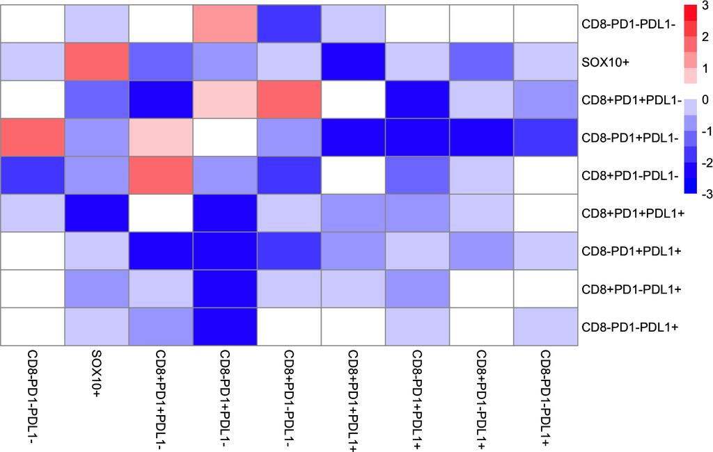

```r
signifPlot(spicyTestBootstrap, breaks=c(-3, 3, 0.5))
```

Indeed, we get improved statistical power compared to the previous method.